# SPX Greek Sensitivity Across Market Regimes

**Repo:** https://github.com/ifrancis2313/spx-greek-regimes

Does market regime change how sensitive SPX option Greeks are to market moves — and does that matter for hedging? This combines the three notebooks of the project (Structural Instability → Regime Classification → Greek Sensitivity Panel) into one document, in run order, with all code, output, and commentary as executed.

# Part 1 — Structural Instability in Greek Sensitivity

**Output**: Rolling coefficient plots + Chow test results for structural breaks.

```python
import sys
sys.path.insert(0, '../src')

import pandas as pd
import numpy as np
import matplotlib.pyplot as plt

from features import build_daily_features
from rolling_regression import rolling_ols, chow_test, rolling_coefficient_summary
from plots import plot_rolling_coefficients, KNOWN_CRISES

DATA = '../data'
```

```python
# Load daily features (used as both Y candidates and X variables)
features = build_daily_features(
    f'{DATA}/cboeall1986.parquet',
    f'{DATA}/ff3.parquet',
    f'{DATA}/spx_clean.parquet',
)
print(f'Feature set: {len(features)} trading days')
features.head()
```

```
Feature set: 6022 trading days
```

|  | date | vix | vrp | momentum | opt_spread |
| --- | --- | --- | --- | --- | --- |
| 0 | 1996-01-30 | 12.42 | 0.053911 | 0.0190 | 0.2500 |
| 1 | 1996-01-31 | 12.53 | -0.132896 | 0.0214 | 0.3750 |
| 2 | 1996-02-01 | 12.65 | 0.397681 | 0.0265 | 0.2500 |
| 3 | 1996-02-02 | 13.23 | 0.926599 | 0.0318 | 0.2500 |
| 4 | 1996-02-05 | 13.46 | 0.972832 | 0.0408 | 0.3125 |

```python
# Load SPX options — compute daily mean delta and gamma as Y variables
opts = pd.read_parquet(f'{DATA}/spx_clean.parquet')
opts['date'] = pd.to_datetime(opts['date'])
opts = opts[(opts['days_to_exp'].between(20, 45)) & (opts['put'] == 1)]

daily_greeks = opts.groupby('date')[['delta', 'gamma', 'vega', 'theta']].mean()
daily_greeks.columns = [f'avg_{c}' for c in daily_greeks.columns]

# Merge with features for X variables
panel = features.set_index('date').join(daily_greeks, how='inner')
panel = panel.sort_index()
print(f'Merged panel: {len(panel)} days')
panel.head()
```

```
Merged panel: 4123 days
```

| date | vix | vrp | momentum | opt_spread | avg_delta | avg_gamma | avg_vega | avg_theta |
| --- | --- | --- | --- | --- | --- | --- | --- | --- |
| 1996-01-31 | 12.53 | -0.132896 | 0.0214 | 0.3750 | -0.033237 | 0.001861 | 16.157140 | -11.906750 |
| 1996-02-01 | 12.65 | 0.397681 | 0.0265 | 0.2500 | -0.016504 | 0.000886 | 8.898182 | -7.991354 |
| 1996-02-02 | 13.23 | 0.926599 | 0.0318 | 0.2500 | -0.004762 | 0.000228 | 2.949301 | -3.662386 |
| 1996-02-05 | 13.46 | 0.972832 | 0.0408 | 0.3125 | -0.004592 | 0.000212 | 2.773273 | -3.987398 |
| 1996-02-06 | 14.59 | 4.066182 | 0.0452 | 0.2500 | -0.016689 | 0.000817 | 8.536281 | -10.098290 |

```
Panel with mktrf: 4123 days
```

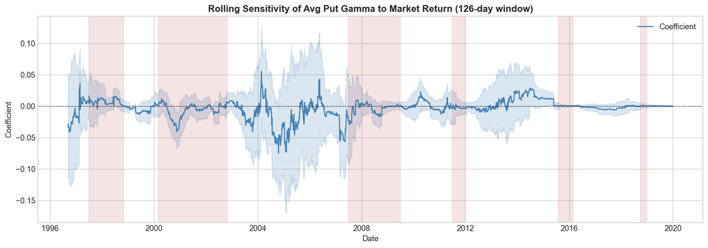

```python
# --- Rolling regression: avg_gamma ~ VIX + mktrf (daily) ---
ff3 = pd.read_parquet(f'{DATA}/ff3.parquet')
ff3['date'] = pd.to_datetime(ff3['date'])
panel = panel.join(ff3.set_index('date')[['mktrf']], how='inner')
print(f'Panel with mktrf: {len(panel)} days')

rolling_gamma = rolling_ols(y=panel['avg_gamma'], X=panel[['vix', 'mktrf']], window=126)
fig = plot_rolling_coefficients(
    rolling_gamma,
    coef_col='mktrf_coef',
    se_col='mktrf_se',
    title='Rolling Sensitivity of Avg Put Gamma to Market Return (126-day window)',
)
plt.show()
```

**Why this motivates Part 2:** the named crisis windows do show distinct average sensitivity levels, but notice that the "calm (all other)" bucket — the 2,586 days left over once the six known crises are carved out — has the *largest* standard deviation of any group (0.0173, wider than every individual crisis window). That bucket isn't actually homogeneous: it's a grab-bag of genuine calm, mild rising stress, and recovery, all lumped together because they don't fall inside a hand-picked historical crisis date range. A binary calm/crisis split — or any rule based on fixed historical windows — throws away exactly the structure we care about. That's the gap the 4-state HMM in Part 2 is built to close: instead of hand-picked windows, let the data itself define when a regime starts and ends.

```python
# --- Chow test at GFC start (2007-07-01) ---
breakpoint_date = pd.Timestamp('2007-07-01')
breakpoint_idx = int(panel.index.searchsorted(breakpoint_date))
print(f'Breakpoint index: {breakpoint_idx} ({panel.index[breakpoint_idx].date()})')

chow_result = chow_test(y=panel['avg_gamma'], X=panel[['vix', 'mktrf']], breakpoint_idx=breakpoint_idx)
chow_result
```

```
Breakpoint index: 2385 (2007-07-05)
```

```
{'f_stat': np.float64(29.6814),
 'p_value': 0.0,
 'breakpoint_idx': 2385,
 'reject_h0': True}
```

```python
# --- Rolling coefficient summary table ---
summary_mktrf = rolling_coefficient_summary(rolling_gamma, coef_col='mktrf_coef', crisis_periods=KNOWN_CRISES)
summary_vix = rolling_coefficient_summary(rolling_gamma, coef_col='vix_coef', crisis_periods=KNOWN_CRISES)

print('Market-return sensitivity (mktrf_coef) by period:')
display(summary_mktrf)
print()
print('VIX sensitivity (vix_coef) by period:')
display(summary_vix)
```

```
Market-return sensitivity (mktrf_coef) by period:
```

|  | period | mean | std | min | max | n_days |
| --- | --- | --- | --- | --- | --- | --- |
| 0 | Asian+LTCM | 0.0071 | 0.0043 | -0.0050 | 0.0163 | 279 |
| 1 | Dot-com | -0.0067 | 0.0109 | -0.0408 | 0.0113 | 555 |
| 2 | GFC | -0.0036 | 0.0081 | -0.0297 | 0.0099 | 398 |
| 3 | Euro debt | -0.0024 | 0.0015 | -0.0056 | 0.0032 | 101 |
| 4 | China shock | 0.0004 | 0.0002 | 0.0002 | 0.0007 | 61 |
| 5 | Q4 2018 | 0.0004 | 0.0003 | 0.0000 | 0.0009 | 18 |
| 6 | calm (all other) | -0.0058 | 0.0173 | -0.0750 | 0.0553 | 2586 |

```
VIX sensitivity (vix_coef) by period:
```

|  | period | mean | std | min | max | n_days |
| --- | --- | --- | --- | --- | --- | --- |
| 0 | Asian+LTCM | -0.0001 | 0.0001 | -0.0003 | 0.0001 | 279 |
| 1 | Dot-com | -0.0000 | 0.0001 | -0.0002 | 0.0001 | 555 |
| 2 | GFC | -0.0000 | 0.0001 | -0.0001 | 0.0001 | 398 |
| 3 | Euro debt | -0.0000 | 0.0000 | -0.0000 | 0.0000 | 101 |
| 4 | China shock | -0.0000 | 0.0000 | -0.0000 | 0.0000 | 61 |
| 5 | Q4 2018 | -0.0000 | 0.0000 | -0.0000 | -0.0000 | 18 |
| 6 | calm (all other) | -0.0000 | 0.0001 | -0.0004 | 0.0004 | 2586 |

# Part 2 — Market Regime Classification (4-State HMM)

**Goal**: Classify every trading day (1996–2019) into one of four market regimes using a Gaussian HMM trained on:

- VIX level
- Variance Risk Premium (VRP)
- 21-day SPX momentum
- Median options bid-ask spread

**Output**: Daily regime labels, state summary statistics, transition matrix, and crisis validation table.

```python
import sys
sys.path.insert(0, '../src')

import pandas as pd
import numpy as np
import matplotlib.pyplot as plt

from features import build_daily_features
from regime import RegimeClassifier
from plots import plot_regime_timeline

DATA = '../data'
```

```python
# Build feature set
features = build_daily_features(
    f'{DATA}/cboeall1986.parquet',
    f'{DATA}/ff3.parquet',
    f'{DATA}/spx_clean.parquet',
)
print(f'{len(features)} trading days')
features.describe().round(3)
```

```
6022 trading days
```

|  | date | vix | vrp | momentum | opt_spread |
| --- | --- | --- | --- | --- | --- |
| count | 6022 | 6022.000 | 6022.000 | 6022.000 | 6022.000 |
| mean | 2008-01-14 16:02:28.256393 | 19.959 | 3.747 | 0.009 | 0.964 |
| min | 1996-01-30 00:00:00 | 9.140 | -32.718 | -0.337 | 0.062 |
| 25% | 2002-01-25 18:00:00 | 14.080 | 1.683 | -0.014 | 0.500 |
| 50% | 2008-01-15 12:00:00 | 18.370 | 3.987 | 0.015 | 0.825 |
| 75% | 2014-01-07 18:00:00 | 23.458 | 6.522 | 0.037 | 1.200 |
| max | 2019-12-31 00:00:00 | 80.860 | 23.881 | 0.226 | 14.950 |
| std | NaN | 8.130 | 4.733 | 0.047 | 0.718 |

```python
# Fit 4-state HMM
clf = RegimeClassifier(n_states=4, random_state=42)
clf.fit(features)
state_names = clf.label_states(features)
print('State name mapping:', state_names)
```

```
State name mapping: {2: 'calm', 0: 'rising_stress', 1: 'recovery', 3: 'crisis'}
```

```python
# State summary statistics
clf.state_summary(features)
```

| state | vix mean | vix std | vrp mean | vrp std | momentum mean | momentum std | opt_spread mean | opt_spread std |
| --- | --- | --- | --- | --- | --- | --- | --- | --- |
| calm | 12.6373 | 1.6450 | 3.9678 | 1.7390 | 0.0163 | 0.0207 | 0.6422 | 0.3420 |
| crisis | 32.6768 | 10.4521 | 0.1182 | 7.7579 | -0.0168 | 0.0810 | 1.7673 | 1.2536 |
| recovery | 22.8160 | 3.6648 | 4.5011 | 4.5374 | 0.0086 | 0.0470 | 0.9876 | 0.4399 |
| rising_stress | 16.8986 | 2.5023 | 4.6343 | 3.6595 | 0.0157 | 0.0327 | 0.8075 | 0.4457 |

**States are cleanly separated by VIX, as expected** (calm 12.6 → rising_stress 16.9 → recovery 22.8 → crisis 32.7) — but note that `recovery` has a *higher* mean VIX than `rising_stress`, not lower. That's not a labeling mistake: `recovery` follows a crisis and is still de-escalating from an elevated level, while `rising_stress` is the early build-up phase starting from calm. The HMM is picking up path-dependent structure, not just sorting days by VIX level.

The VRP column shows the same counterintuitive pattern noted in the project's domain notes: VRP averages **0.12 in crisis** versus **3.97–4.63 in every other state**. Realized volatility spikes faster than implied volatility (VIX) can reprice, so the premium option sellers earn for bearing volatility risk collapses exactly when risk is highest — a textbook crisis-vol-premium-compression effect, recovered here without it being hand-fed to the model.

Diagonal probabilities of 0.96–0.98 mean regimes are highly persistent — the model isn't flickering between states day to day, it's identifying genuine multi-week-to-multi-month episodes, which is what you'd want from a market-regime label.

```python
# Transition matrix
clf.transition_matrix()
```

|  | rising_stress | recovery | calm | crisis |
| --- | --- | --- | --- | --- |
| rising_stress | 0.9647 | 0.0149 | 0.0166 | 0.0038 |
| recovery | 0.0178 | 0.9694 | 0.0000 | 0.0128 |
| calm | 0.0205 | 0.0000 | 0.9781 | 0.0014 |
| crisis | 0.0038 | 0.0286 | 0.0020 | 0.9656 |

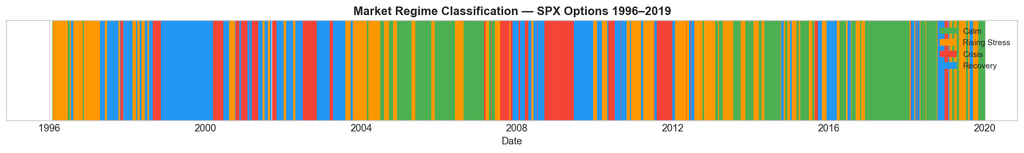

```python
# Regime timeline
named_labels = clf.predict_named(features)
fig = plot_regime_timeline(features['date'], named_labels)
plt.show()
```

```python
# Crisis validation — do HMM states align with known events?
clf.crisis_validation(features['date'], named_labels)
```

|  | crisis | dominant_regime | regime_share |
| --- | --- | --- | --- |
| 0 | Asian + LTCM | recovery | 0.564 |
| 1 | Dot-com | crisis | 0.437 |
| 2 | GFC | crisis | 0.587 |
| 3 | Euro debt | crisis | 0.819 |
| 4 | China shock | recovery | 0.552 |
| 5 | Q4 2018 | recovery | 0.698 |

```python
# Save regime labels for use in Part 3
regime_output = features[['date']].copy()
regime_output['regime'] = named_labels.values
regime_output.to_parquet(f'{DATA}/regime_labels.parquet', index=False)
print('Saved data/regime_labels.parquet')
regime_output['regime'].value_counts()
```

```
Saved data/regime_labels.parquet
```

```
regime
rising_stress    1854
recovery         1762
calm             1495
crisis            911
Name: count, dtype: int64
```

```python
# Robustness: 3-state HMM
clf3 = RegimeClassifier(n_states=3, random_state=42)
clf3.fit(features)
clf3.label_states(features)
print('3-state transition matrix:')
display(clf3.transition_matrix())
print('\n3-state crisis validation:')
display(clf3.crisis_validation(features['date'], clf3.predict_named(features)))
```

```
3-state transition matrix:
```

|  | recovery | rising_stress | calm |
| --- | --- | --- | --- |
| recovery | 0.9651 | 0.0305 | 0.0044 |
| rising_stress | 0.0120 | 0.9772 | 0.0108 |
| calm | 0.0026 | 0.0099 | 0.9875 |

```
3-state crisis validation:
```

|  | crisis | dominant_regime | regime_share |
| --- | --- | --- | --- |
| 0 | Asian + LTCM | rising_stress | 0.766 |
| 1 | Dot-com | rising_stress | 0.537 |
| 2 | GFC | recovery | 0.605 |
| 3 | Euro debt | recovery | 0.835 |
| 4 | China shock | rising_stress | 0.600 |
| 5 | Q4 2018 | rising_stress | 0.794 |

# Part 3 — Greek Sensitivity Across Market Regimes

**Goal**: Quantify how the sensitivity of option Greeks (delta, gamma, vega, theta) to market moves changes across the four HMM-identified regimes.

**Model**: ΔGreek = α + β₁·ΔMarket + β₂·ΔVIX + Σγₖ·(Regimeₖ × ΔMarket) + ε

The γₖ coefficients measure additional Greek sensitivity vs. the calm baseline.

**Samples**:

- Primary: 20–45 DTE (active hedging window)
- Robustness: 5–20 DTE (FOMC window)

**Stratification**: Puts and calls analyzed separately. Moneyness buckets: deep OTM, OTM, ATM.

```python
import sys
sys.path.insert(0, '../src')

import pandas as pd
import numpy as np
import matplotlib.pyplot as plt

from panel import build_panel
from sensitivity import run_all, interaction_table
from plots import plot_sensitivity_heatmap, plot_put_call_comparison

DATA = '../data'
```

```python
# Load regime labels from Part 2
regime_labels = pd.read_parquet(f'{DATA}/regime_labels.parquet')
regime_labels['date'] = pd.to_datetime(regime_labels['date'])
print(regime_labels['regime'].value_counts())

# Load market features for regression covariates
ff3 = pd.read_parquet(f'{DATA}/ff3.parquet')
ff3['date'] = pd.to_datetime(ff3['date'])
vix = pd.read_parquet(f'{DATA}/cboeall1986.parquet')
vix['date'] = pd.to_datetime(vix['Date'])
market_features = ff3[['date','mktrf']].merge(vix[['date','vix']].dropna(), on='date', how='inner')
market_features = market_features[
    (market_features['date'] >= '1996-01-01') & (market_features['date'] <= '2019-12-31')
]
```

```
regime
rising_stress    1854
recovery         1762
calm             1495
crisis            911
Name: count, dtype: int64
```

```python
# Build primary sample panel (20–45 DTE)
puts, calls = build_panel(
    f'{DATA}/spx_raw.parquet',
    regime_labels,
    market_features,
    dte_min=20,
    dte_max=45,
)
print(f'Puts panel: {len(puts):,} observations | {puts["contract_id"].nunique():,} contracts')
print(f'Calls panel: {len(calls):,} observations | {calls["contract_id"].nunique():,} contracts')
```

```
Puts panel: 738,118 observations | 69,552 contracts
Calls panel: 460,886 observations | 42,313 contracts
```

```python
# Run all regressions — puts
puts_results = run_all(puts)
puts_results.head(20)
```

|  | greek | moneyness | parameter | coef | se | t_stat | p_value | significant | n_obs |
| --- | --- | --- | --- | --- | --- | --- | --- | --- | --- |
| 0 | delta | deep_otm | const | 0.004384 | 2.420966e-05 | 181.100572 | 0.000000e+00 | True | 458930 |
| 1 | delta | deep_otm | mktrf | 2.144310 | 1.042750e-02 | 205.639985 | 0.000000e+00 | True | 458930 |
| 2 | delta | deep_otm | vix_chg | -0.002248 | 4.341417e-05 | -51.775503 | 0.000000e+00 | True | 458930 |
| 3 | delta | deep_otm | interact_crisis | -1.246579 | 1.541086e-02 | -80.889624 | 0.000000e+00 | True | 458930 |
| 4 | delta | deep_otm | interact_recovery | -0.778433 | 1.266279e-02 | -61.474025 | 0.000000e+00 | True | 458930 |
| 5 | delta | deep_otm | interact_rising_stress | -0.408972 | 1.384347e-02 | -29.542625 | 8.168102e-192 | True | 458930 |
| 6 | delta | otm | const | 0.008482 | 7.297797e-05 | 116.223465 | 0.000000e+00 | True | 135140 |
| 7 | delta | otm | mktrf | 7.979638 | 3.230053e-02 | 247.043583 | 0.000000e+00 | True | 135140 |
| 8 | delta | otm | vix_chg | -0.004856 | 1.597924e-04 | -30.391616 | 7.089193e-203 | True | 135140 |
| 9 | delta | otm | interact_crisis | -5.451268 | 3.936181e-02 | -138.491308 | 0.000000e+00 | True | 135140 |
| 10 | delta | otm | interact_recovery | -3.458768 | 3.240187e-02 | -106.745945 | 0.000000e+00 | True | 135140 |
| 11 | delta | otm | interact_rising_stress | -2.302877 | 3.559806e-02 | -64.691084 | 0.000000e+00 | True | 135140 |
| 12 | delta | atm | const | 0.001956 | 1.221193e-04 | 16.014558 | 1.011235e-57 | True | 80033 |
| 13 | delta | atm | mktrf | 10.495065 | 4.941363e-02 | 212.392092 | 0.000000e+00 | True | 80033 |
| 14 | delta | atm | vix_chg | -0.005640 | 1.642549e-04 | -34.334127 | 2.430371e-258 | True | 80033 |
| 15 | delta | atm | interact_crisis | -7.323636 | 6.249953e-02 | -117.179059 | 0.000000e+00 | True | 80033 |
| 16 | delta | atm | interact_recovery | -4.788486 | 5.264630e-02 | -90.955800 | 0.000000e+00 | True | 80033 |
| 17 | delta | atm | interact_rising_stress | -3.297211 | 5.764908e-02 | -57.194507 | 0.000000e+00 | True | 80033 |
| 18 | gamma | deep_otm | const | -0.000026 | 2.405737e-07 | -108.318783 | 0.000000e+00 | True | 458930 |
| 19 | gamma | deep_otm | mktrf | -0.027271 | 1.141278e-04 | -238.950944 | 0.000000e+00 | True | 458930 |

```python
# Run all regressions — calls
calls_results = run_all(calls)
calls_results.head(20)
```

|  | greek | moneyness | parameter | coef | se | t_stat | p_value | significant | n_obs |
| --- | --- | --- | --- | --- | --- | --- | --- | --- | --- |
| 0 | delta | deep_otm | const | -0.006534 | 5.356369e-05 | -121.979065 | 0.000000e+00 | True | 201917 |
| 1 | delta | deep_otm | mktrf | 3.487906 | 2.338134e-02 | 149.174773 | 0.000000e+00 | True | 201917 |
| 2 | delta | deep_otm | vix_chg | -0.000546 | 5.759006e-05 | -9.486290 | 2.394025e-21 | True | 201917 |
| 3 | delta | deep_otm | interact_crisis | -2.498248 | 2.798136e-02 | -89.282562 | 0.000000e+00 | True | 201917 |
| 4 | delta | deep_otm | interact_recovery | -1.469465 | 2.884940e-02 | -50.935736 | 0.000000e+00 | True | 201917 |
| 5 | delta | deep_otm | interact_rising_stress | -1.059552 | 3.191640e-02 | -33.197724 | 1.161120e-241 | True | 201917 |
| 6 | delta | otm | const | -0.006661 | 1.078522e-04 | -61.759815 | 0.000000e+00 | True | 85138 |
| 7 | delta | otm | mktrf | 10.248862 | 4.263722e-02 | 240.373611 | 0.000000e+00 | True | 85138 |
| 8 | delta | otm | vix_chg | -0.003638 | 1.767226e-04 | -20.583768 | 3.836671e-94 | True | 85138 |
| 9 | delta | otm | interact_crisis | -7.341752 | 5.882924e-02 | -124.797652 | 0.000000e+00 | True | 85138 |
| 10 | delta | otm | interact_recovery | -4.578599 | 4.771923e-02 | -95.948708 | 0.000000e+00 | True | 85138 |
| 11 | delta | otm | interact_rising_stress | -3.125586 | 5.242370e-02 | -59.621616 | 0.000000e+00 | True | 85138 |
| 12 | delta | atm | const | 0.002975 | 1.194159e-04 | 24.911544 | 5.578423e-137 | True | 79734 |
| 13 | delta | atm | mktrf | 10.981897 | 5.120699e-02 | 214.460911 | 0.000000e+00 | True | 79734 |
| 14 | delta | atm | vix_chg | -0.004007 | 2.346664e-04 | -17.074844 | 2.284349e-65 | True | 79734 |
| 15 | delta | atm | interact_crisis | -7.728462 | 7.004560e-02 | -110.334720 | 0.000000e+00 | True | 79734 |
| 16 | delta | atm | interact_recovery | -4.907790 | 5.599689e-02 | -87.643959 | 0.000000e+00 | True | 79734 |
| 17 | delta | atm | interact_rising_stress | -3.387563 | 5.967853e-02 | -56.763513 | 0.000000e+00 | True | 79734 |
| 18 | gamma | deep_otm | const | -0.000046 | 9.229610e-07 | -49.827372 | 0.000000e+00 | True | 201917 |
| 19 | gamma | deep_otm | mktrf | 0.091246 | 4.984658e-04 | 183.053093 | 0.000000e+00 | True | 201917 |

```python
# Interaction coefficient table (γ matrix)
print('PUTS — Interaction (γ) coefficients:')
display(interaction_table(puts_results))
print('\nCALLS — Interaction (γ) coefficients:')
display(interaction_table(calls_results))
```

```
PUTS — Interaction (γ) coefficients:
```

| greek regime moneyness | delta crisis | delta recovery | delta rising_stress | gamma crisis | gamma recovery | gamma rising_stress | theta crisis | theta recovery | theta rising_stress | vega crisis | vega recovery | vega rising_stress |
| --- | --- | --- | --- | --- | --- | --- | --- | --- | --- | --- | --- | --- |
| atm | -7.323636 | -4.788486 | -3.297211 | -0.002882 | -0.000824 | 0.000788 | -89.020324 | 354.979140 | 472.064232 | -94.265538 | -184.460042 | -268.881633 |
| deep_otm | -1.246579 | -0.778433 | -0.408972 | 0.020007 | 0.014919 | 0.008554 | -615.029089 | -62.473535 | 98.390091 | 1393.328488 | 771.901934 | 478.452010 |
| otm | -5.451268 | -3.458768 | -2.302877 | 0.043037 | 0.034382 | 0.024926 | -1064.011000 | -41.052410 | 231.087080 | 2256.323127 | 1324.204075 | 859.293207 |

```
CALLS — Interaction (γ) coefficients:
```

| greek regime moneyness | delta crisis | delta recovery | delta rising_stress | gamma crisis | gamma recovery | gamma rising_stress | theta crisis | theta recovery | theta rising_stress | vega crisis | vega recovery | vega rising_stress |
| --- | --- | --- | --- | --- | --- | --- | --- | --- | --- | --- | --- | --- |
| atm | -7.728462 | -4.907790 | -3.387563 | -0.012693 | -0.010975 | -0.005118 | -274.686162 | -114.086403 | 229.748700 | -321.532890 | -213.905699 | -250.534794 |
| deep_otm | -2.498248 | -1.469465 | -1.059552 | -0.078241 | -0.060732 | -0.040924 | 621.425312 | 136.172277 | 223.591482 | -2373.353385 | -1371.982519 | -1012.365022 |
| otm | -7.341752 | -4.578599 | -3.125586 | -0.090140 | -0.071937 | -0.046552 | 711.783043 | 282.830203 | 410.042550 | -3148.258706 | -2025.118733 | -1534.065963 |

**Headline result — ATM gamma, puts vs. calls:** the calm-baseline `mktrf` coefficient for ATM put gamma is -0.00071; the crisis interaction adds another -0.00288, for a combined crisis-period sensitivity of about -0.0036 — **roughly 5x the calm-baseline magnitude**, same sign. ATM call gamma moves the opposite way: calm baseline +0.0123, crisis interaction -0.0127, leaving crisis-period sensitivity essentially flat (≈ -0.0004) — **the relationship nearly cancels out**. Puts and calls are not mirror images of each other under stress.

It's not just an ATM story, and it isn't uniform across moneyness either. For **calls**, every moneyness bucket sees the crisis interaction *oppose* the calm baseline, shrinking sensitivity by 86–100% (deep OTM and OTM calls keep most of their sign, just much smaller; ATM nearly flips). For **puts**, deep OTM and OTM gamma sensitivity also *shrinks* in crisis (interaction opposes baseline, dropping ~75%) — but ATM puts go the other way entirely, with the interaction reinforcing the baseline and amplifying it. So crisis doesn't uniformly amplify or dampen gamma exposure; the direction itself depends on both moneyness and option type, which is the kind of structure a single market-wide "vol regime" adjustment would never recover.

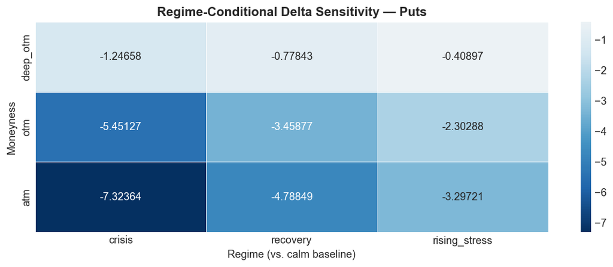

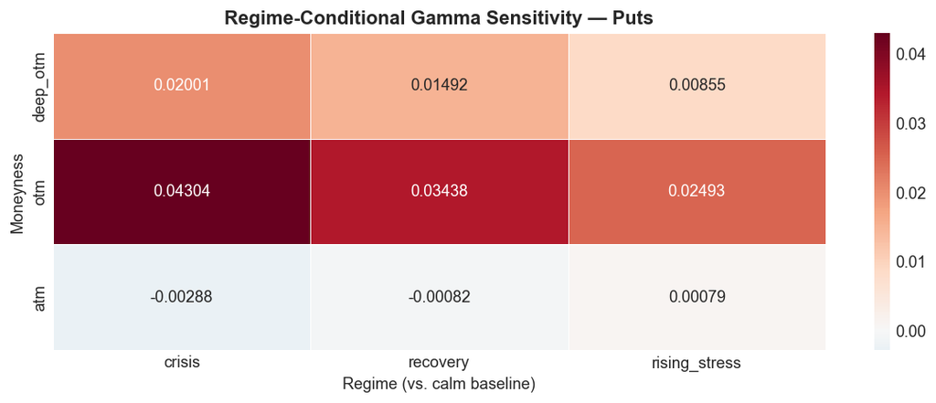

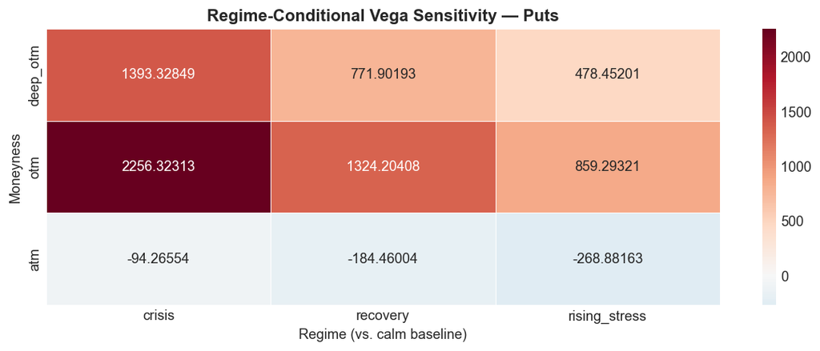

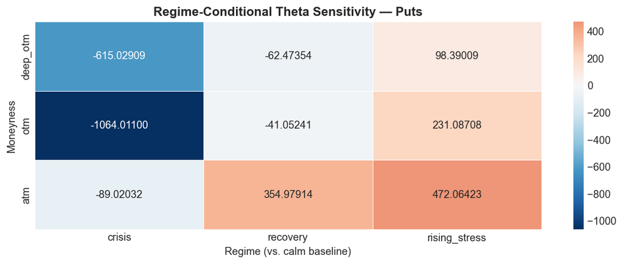

```python
# Heatmaps — puts
for greek in ['delta', 'gamma', 'vega', 'theta']:
    fig = plot_sensitivity_heatmap(puts_results, greek, instrument='puts')
    plt.show()
```

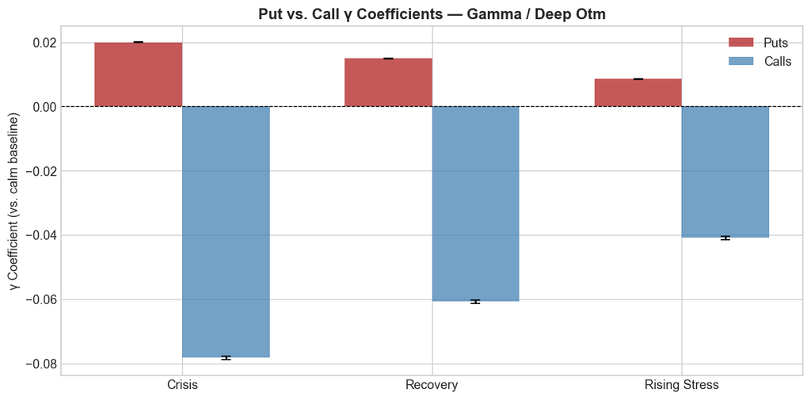

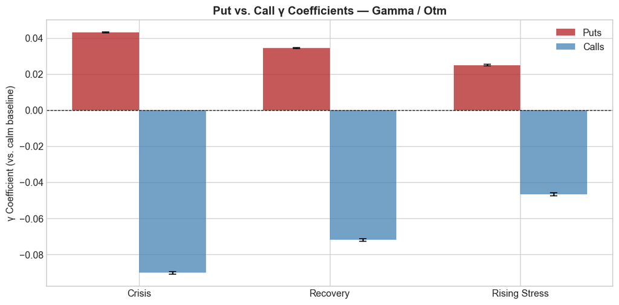

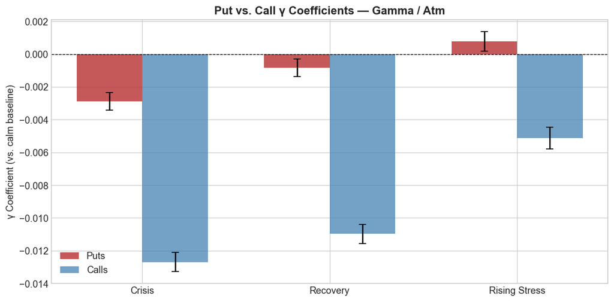

```python
# Put vs. call comparison for gamma (the most hedging-relevant Greek)
for bucket in ['deep_otm', 'otm', 'atm']:
    fig = plot_put_call_comparison(puts_results, calls_results, 'gamma', bucket)
    plt.show()
```

**Reading the bars:** the call bars are taller than the put bars in every bucket here — calls have the larger *raw* regime interaction coefficient throughout. That looks like it contradicts the "puts are more crisis-sensitive" framing above, but it doesn't: calls also start from a much larger calm-baseline coefficient in the opposite direction, so a big call interaction mostly cancels its own baseline rather than adding to it. Puts start from a small (ATM) or negative (OTM/deep OTM) baseline, so the same-sized or even smaller interaction has more room to swing the *total* sensitivity around. The bar chart shows the size of the regime adjustment; the headline finding above is about what that adjustment does to the total — and those are genuinely different questions.

```python
# Robustness: FOMC window (5–20 DTE)
puts_fomc, calls_fomc = build_panel(
    f'{DATA}/spx_raw.parquet',
    regime_labels,
    market_features,
    dte_min=5,
    dte_max=20,
)
print(f'FOMC puts: {len(puts_fomc):,} | calls: {len(calls_fomc):,}')
puts_fomc_results = run_all(puts_fomc)
calls_fomc_results = run_all(calls_fomc)
print('\nFOMC Puts γ:')
display(interaction_table(puts_fomc_results))
print('\nFOMC Calls γ:')
display(interaction_table(calls_fomc_results))
```

```
FOMC puts: 566,162 | calls: 351,048
```

```
FOMC Puts γ:
```

| greek regime moneyness | delta crisis | delta recovery | delta rising_stress | gamma crisis | gamma recovery | gamma rising_stress | theta crisis | theta recovery | theta rising_stress | vega crisis | vega recovery | vega rising_stress |
| --- | --- | --- | --- | --- | --- | --- | --- | --- | --- | --- | --- | --- |
| atm | -12.565574 | -8.945259 | -6.640956 | -0.038955 | -0.031476 | -0.026791 | -179.669443 | 1730.766631 | 1675.622762 | -291.214804 | -479.194692 | -505.620434 |
| deep_otm | -1.282930 | -0.805552 | -0.551459 | 0.044733 | 0.034232 | 0.023960 | -86.872619 | 591.435458 | 534.019601 | 1042.357371 | 576.331149 | 405.643778 |
| otm | -9.821400 | -6.848477 | -5.149549 | 0.110738 | 0.092628 | 0.070482 | -1713.230611 | 964.056638 | 1167.338170 | 2289.248597 | 1360.516260 | 921.685848 |

```
FOMC Calls γ:
```

| greek regime moneyness | delta crisis | delta recovery | delta rising_stress | gamma crisis | gamma recovery | gamma rising_stress | theta crisis | theta recovery | theta rising_stress | vega crisis | vega recovery | vega rising_stress |
| --- | --- | --- | --- | --- | --- | --- | --- | --- | --- | --- | --- | --- |
| atm | -12.859027 | -8.689677 | -6.332634 | -0.055231 | -0.052504 | -0.040458 | -1124.590788 | 45.995919 | 960.300487 | -247.735761 | -298.673875 | -322.525233 |
| deep_otm | -3.055445 | -1.520043 | -1.180781 | -0.154144 | -0.119979 | -0.085861 | 1171.396645 | -141.590010 | 399.148315 | -1841.692724 | -1003.646309 | -781.477156 |
| otm | -11.703648 | -7.653590 | -5.535185 | -0.237302 | -0.202447 | -0.152805 | 1331.329380 | 577.564965 | 1311.702066 | -3046.189778 | -2187.913887 | -1758.403105 |

## Summary of findings

Returning to the question this paper opened with — *does the regime matter for hedging, and how much more sensitive is gamma to a 1% market move during a crisis than a calm period?* — the answer is yes, and "how much" depends on which instrument and which moneyness you ask about:

- **ATM put gamma is ~5x more sensitive to market moves in crisis than in calm regimes**, same direction as the calm baseline (amplification).
- **ATM call gamma sensitivity nearly cancels out in crisis** — the calm-period relationship all but disappears once a crisis interaction is added, rather than amplifying.
- Away from ATM, the picture flips again: **OTM and deep-OTM gamma sensitivity shrinks in crisis for both puts and calls**, the opposite of the ATM put result.
- This is not an artifact of the 20–45 DTE window choice: the 5–20 DTE FOMC robustness check reproduces the same qualitative story (crisis materially reweights gamma sensitivity, in a moneyness- and instrument-dependent way) even though the specific calm-baseline coefficients differ across DTE windows.
- All of this sits on top of a structural justification from Parts 1–2: a single unconditional regression is formally rejected by a Chow test at the GFC break (F=29.68, p≈0), and a 4-state regime model is preferred over 3 states because the 3-state version assigns every known historical crisis to a generic "stress" label with no dedicated crisis state at all.

**Practical read for hedging:** a market maker holding a uniform "vol regime" adjustment to their gamma book would get the sign wrong for some positions and the magnitude wrong for almost all of them. The adjustment needs to vary by moneyness and by option type, not just by regime.